# scRNA-seq Rat Metrial Glands

Ha T. H. Vu

This is a documentation for analyses of scRNA-seq data, generated from rat metrial gland tissues on gestational day (GD) 15.5 and 19.5.

In this step, we will explore the conserved markers between rat and human trophoblast cells. We first carry out enrichment analysis with `PlacentaCellEnrich`. We combine markers of rat invasive trophoblast clusters at both timepoints, and compare the gene list with human placenta single cell data from Vento-Tormo et al., Suryawanshi et al., Xiang et al., Castel et al., and Liu et al.

```r
library("TissueEnrich")
```

```r
library("tidyverse")
library("patchwork")

load(file = "/work/LAS/geetu-lab/hhvu/combine-test-expression1.Rdata")

ratHumanOrthologs <- dataset$GRCH38$ratHumanOrthologs
humanGeneMapping <- dataset$GRCH38$humanGeneMapping

s1 <- read.table("/work/LAS/geetu-lab/hhvu/project3_scATAC/scRNA-seq-analysis/7_conserved/gd15.5-wilcoxin-cluster23-genes.txt", header = F)
s2 <- read.table("/work/LAS/geetu-lab/hhvu/project3_scATAC/scRNA-seq-analysis/7_conserved/gd19.5-wilcoxin-cluster6-genes.txt", header = F)

plotFunc <- function(data, name) {
  p<-ggplot(data,aes(x=reorder(Tissue,-Log10PValue),y=Log10PValue,
                     label = Tissue, fill = Tissue, width=0.8))+
    scale_fill_manual(values=color) +
    geom_bar(stat = 'identity', show.legend = FALSE)+
    labs(x='', y = '-log10(adj. p-value)')+
    theme_bw()+
    #theme(legend.position='none', plot.margin=unit(c(1,1,1,2),"cm"))+
    theme(plot.title = element_text(hjust = 0.5, size = 20), axis.title = element_text(size=20))+
    theme(axis.text.x = element_text(angle = 45, vjust = 1, hjust = 1, size=20),
          panel.grid.major= element_blank(),panel.grid.minor = element_blank())+
    ggtitle(name)
  return(p)
}
```

Carry out analysis with Vento-Tormo et al. data:

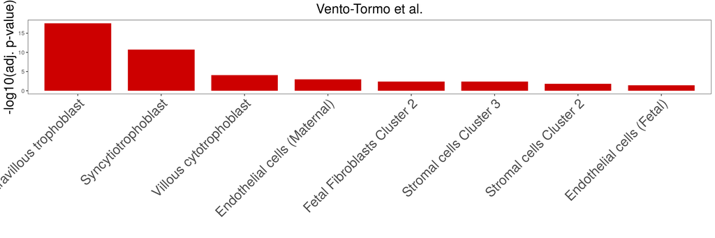

```r
#VentoTormo Data
d<-dataset$PlacentaDeciduaBloodData
data<-d$expressionData
cellDetails<-d$cellDetails

organism<-"Rat"
inputGenes<-toupper(unique(c(s1$V1, s2$V1)))
if(organism == "Rat") {
  humanOrthologs<-ratHumanOrthologs[ratHumanOrthologs$Gene.name %in% inputGenes,]
  inputGenes<-humanOrthologs$Human.gene.stable.ID
  expressionData<-data[intersect(row.names(data), ratHumanOrthologs$Human.gene.stable.ID),]
} else {
  #For Human
  expressionData<-data[intersect(row.names(data), humanGeneMapping$Gene),]
}
se<-SummarizedExperiment(assays = SimpleList(as.matrix(expressionData)),rowData = row.names(expressionData),colData = colnames(expressionData))
cellSpecificGenesExp<-teGeneRetrieval(se,expressedGeneThreshold = 1)
gs<-GeneSet(geneIds=toupper(inputGenes))
output2<-teEnrichmentCustom(gs,cellSpecificGenesExp)
enrichmentOutput<-setNames(data.frame(assay(output2[[1]]),row.names = rowData(output2[[1]])[,1]),colData(output2[[1]])[,1])
row.names(cellDetails)<-cellDetails$RName
enrichmentOutput$Tissue<- cellDetails[row.names(enrichmentOutput),"CellName"]

enrichmentOutput <- subset(enrichmentOutput, enrichmentOutput$Log10PValue >= -log10(0.05) &
                             enrichmentOutput$fold.change >= 1.5 &
                             enrichmentOutput$Tissue.Specific.Genes >= 5)

enrichmentOutput <- enrichmentOutput[order(-enrichmentOutput$Log10PValue),]
#write.table(enrichmentOutput, "/work/LAS/geetu-lab/hhvu/project3_scATAC/scRNA-seq-analysis/7_conserved/ventoTormo.txt", sep = "\t", quote = F, row.names = T)

color <- rep("red3", dim(enrichmentOutput)[1])
names(color) <- enrichmentOutput$Tissue
plotFunc(enrichmentOutput, "Vento-Tormo et al.")
```

```r
tpm1genesVT <- rownames(expressionData[expressionData$EVT >= 1 & rownames(expressionData) %in% inputGenes, ])
tpm1genesVT <- ratHumanOrthologs[ratHumanOrthologs$Human.gene.stable.ID %in% tpm1genesVT, "Human.gene.name"]
```

Carry out analysis with Suryawanshi et al. data:

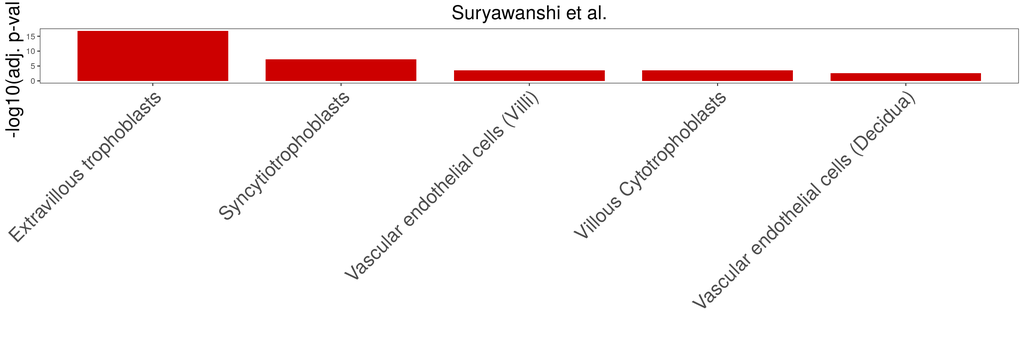

```r
#Suryawanshi
d<-dataset$villiDeciduaData
data<-d$expressionData
cellDetails<-d$cellDetails

organism<-"Rat"
inputGenes<-toupper(c(s1$V1, s2$V1))
if(organism == "Rat") {
  humanOrthologs<-ratHumanOrthologs[ratHumanOrthologs$Gene.name %in% inputGenes,]
  inputGenes<-humanOrthologs$Human.gene.name
  expressionData<-data[intersect(row.names(data), ratHumanOrthologs$Human.gene.name),]
} else {
  #For Human
  expressionData<-data[intersect(row.names(data), humanGeneMapping$Gene),]
}
se<-SummarizedExperiment(assays = SimpleList(as.matrix(expressionData)),rowData = row.names(expressionData),colData = colnames(expressionData))
cellSpecificGenesExp<-teGeneRetrieval(se,expressedGeneThreshold = 1)
gs<-GeneSet(geneIds=toupper(inputGenes))
output2<-teEnrichmentCustom(gs,cellSpecificGenesExp)
enrichmentOutput<-setNames(data.frame(assay(output2[[1]]),row.names = rowData(output2[[1]])[,1]),colData(output2[[1]])[,1])
row.names(cellDetails)<-cellDetails$RName
enrichmentOutput$Tissue<- cellDetails[row.names(enrichmentOutput),"CellName"]

enrichmentOutput <- subset(enrichmentOutput, enrichmentOutput$Log10PValue >= -log10(0.05) &
                             enrichmentOutput$fold.change >= 1.5 &
                             enrichmentOutput$Tissue.Specific.Genes >= 5)

enrichmentOutput <- enrichmentOutput[order(-enrichmentOutput$Log10PValue),]
#write.table(enrichmentOutput, "/work/LAS/geetu-lab/hhvu/project3_scATAC/scRNA-seq-analysis/7_conserved/suryawanshi.txt", sep = "\t", quote = F, row.names = T)

color <- rep("red3", dim(enrichmentOutput)[1])
names(color) <- enrichmentOutput$Tissue

plotFunc(enrichmentOutput, "Suryawanshi et al.")
```

```r
tpm1genesSu <- rownames(expressionData[expressionData$EVT >= 1 & rownames(expressionData) %in% inputGenes, ])
```

Carry out analysis with Xiang et al. data:  
The expression and object required for `PlacentaCellEnrich` were obtained from Seetharam et al.

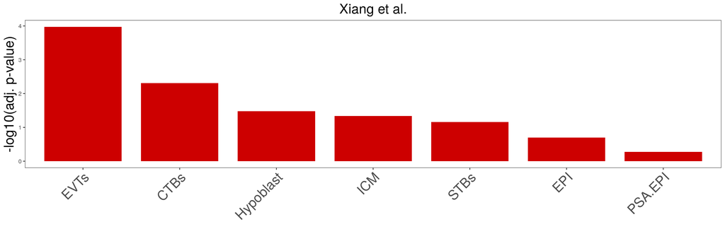

```r
te.dataset.xiang <- readRDS("/work/LAS/geetu-lab/hhvu/project3_scATAC/scRNA-seq-analysis/7_conserved/te.dataset.xiang.rds")
# full names for cell types
xi.md <-  read.csv("/work/LAS/geetu-lab/hhvu/project3_scATAC/scRNA-seq-analysis/7_conserved/md-xi.tsv", sep = "\t", header = TRUE, row.names = 1)
inputGenes<-toupper(c(s1$V1, s2$V1))
humanOrthologs<-ratHumanOrthologs[ratHumanOrthologs$Gene.name %in% inputGenes,]
inputGenes<-humanOrthologs$Human.gene.name
gs <- GeneSet(unique(inputGenes))
output.xi <- teEnrichmentCustom(gs, te.dataset.xiang)
en.output.xi <-
  setNames(data.frame(assay(output.xi[[1]]), row.names = rowData(output.xi[[1]])[, 1]),
           colData(output.xi[[1]])[, 1])
en.output.xi$Tissue <- rownames(en.output.xi)
en.output.xi <- subset(en.output.xi, en.output.xi$Log10PValue >= -log10(0.05) &
                         en.output.xi$fold.change >= 1.5 &
                         en.output.xi$Tissue.Specific.Genes >= 5)
en.output.xi <- en.output.xi[order(-en.output.xi$Log10PValue),]
#write.table(en.output.xi, "/work/LAS/geetu-lab/hhvu/project3_scATAC/scRNA-seq-analysis/7_conserved/xiang.txt", sep = "\t", quote = F, row.names = T)

en.output.xi <-
  setNames(data.frame(assay(output.xi[[1]]), row.names = rowData(output.xi[[1]])[, 1]),
           colData(output.xi[[1]])[, 1])
en.output.xi$Tissue <- rownames(en.output.xi)
en.output.xi <- en.output.xi[order(-en.output.xi$Log10PValue),]
color <- rep("red3", dim(en.output.xi)[1])
plotFunc(en.output.xi, "Xiang et al.")
```

```r
#get expression matrix
cts.xiang <- as.matrix(read.csv("/work/LAS/geetu-lab/hhvu/project3_scATAC/scRNA-seq-analysis/7_conserved/combined_555_rawCounts_tpm.txt", sep = "\t", row.names = "Geneid"))
md.xiang <- read.csv("/work/LAS/geetu-lab/hhvu/project3_scATAC/scRNA-seq-analysis/7_conserved/metadata_555.txt", sep = "\t", header = FALSE, row.names = 1)
mycts.t <- as.data.frame(t(cts.xiang))
metadata <- md.xiang
colnames(metadata) <- c("days", "celltypes")
metadata <- metadata[2]
merged.table <- merge(metadata, mycts.t, by = "row.names", all.x = TRUE)
merged.table <- merged.table %>% remove_rownames %>% column_to_rownames(var = "Row.names")
mycts.mean <- aggregate(. ~ celltypes, merged.table, mean)
ordered <- as.data.frame(t(mycts.mean %>% remove_rownames %>% column_to_rownames(var = "celltypes")))

tpm1genesXi <- rownames(ordered[ordered$EVTs >= 1 & rownames(ordered) %in% inputGenes, ])
```

Carry out analysis with Castel et al. data:  
Same procedure as in analysis with Xiang et al. dataset.

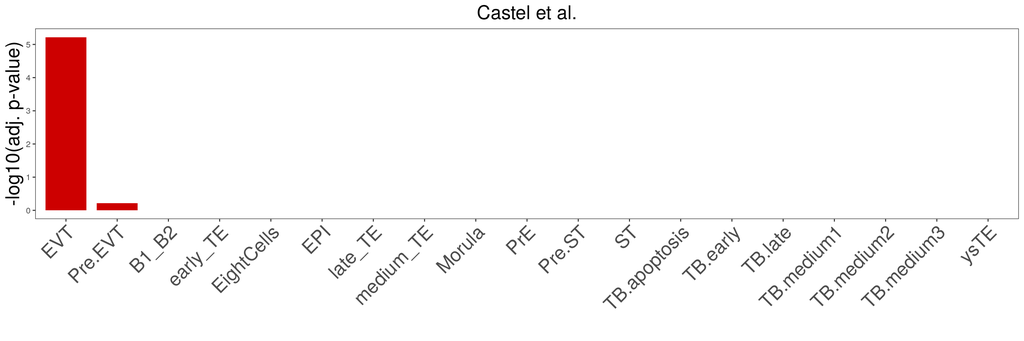

```r
te.dataset.castel <- readRDS("/work/LAS/geetu-lab/hhvu/project3_scATAC/scRNA-seq-analysis/7_conserved/te.dataset.castel.rds")
zp.md <- read.csv("/work/LAS/geetu-lab/hhvu/project3_scATAC/scRNA-seq-analysis/7_conserved/md-zp.tsv", sep = "\t", header = TRUE, row.names = 1)
inputGenes<-toupper(c(s1$V1, s2$V1))
humanOrthologs<-ratHumanOrthologs[ratHumanOrthologs$Gene.name %in% inputGenes,]
inputGenes<-humanOrthologs$Human.gene.name
gs <- GeneSet(unique(inputGenes))
output.zp <- teEnrichmentCustom(gs, te.dataset.castel)
en.output.zp <-
  setNames(data.frame(assay(output.zp[[1]]), row.names = rowData(output.zp[[1]])[, 1]),
           colData(output.zp[[1]])[, 1])
en.output.zp$Tissue <- rownames(en.output.zp)
en.output.zp <- subset(en.output.zp, en.output.zp$Log10PValue >= -log10(0.05) &
                         en.output.zp$fold.change >= 1.5 &
                         en.output.zp$Tissue.Specific.Genes >= 5)
en.output.zp <- en.output.zp[order(-en.output.zp$Log10PValue),]
#write.table(en.output.zp, "/work/LAS/geetu-lab/hhvu/project3_scATAC/scRNA-seq-analysis/7_conserved/castel.txt", sep = "\t", quote = F, row.names = T)

en.output.zp <-
  setNames(data.frame(assay(output.zp[[1]]), row.names = rowData(output.zp[[1]])[, 1]),
           colData(output.zp[[1]])[, 1])
en.output.zp$Tissue <- rownames(en.output.zp)
en.output.zp <- en.output.zp[order(-en.output.zp$Log10PValue),]
color <- rep("red3", dim(en.output.zp)[1])
plotFunc(en.output.zp, "Castel et al.")
```

```r
#build expression matrix
cts.castel <- as.matrix(read.csv("/work/LAS/geetu-lab/hhvu/project3_scATAC/scRNA-seq-analysis/7_conserved/ZhouPetro_rawCounts_tpm.txt", sep = "\t", row.names = "Geneid"))
md.castel <- read.csv("/work/LAS/geetu-lab/hhvu/project3_scATAC/scRNA-seq-analysis/7_conserved/metadata_castel.tsv", sep = "\t", header = FALSE, row.names = 1)
mycts.t <- as.data.frame(t(cts.castel))
metadata <- md.castel
colnames(metadata) <- c("days", "celltypes")
metadata <- metadata[2]
merged.table <- merge(metadata, mycts.t, by = "row.names", all.x = TRUE)
merged.table <- merged.table %>% remove_rownames %>% column_to_rownames(var = "Row.names")
mycts.mean <- aggregate(. ~ celltypes, merged.table, mean)
ordered <- as.data.frame(t(mycts.mean %>% remove_rownames %>% column_to_rownames(var = "celltypes")))

tpm1genesCas <- rownames(ordered[ordered$EVT >= 1 & rownames(ordered) %in% inputGenes, ])
```

Carry out analysis with Liu et al. data:  
This data is not built in with `PlacentaCellEnrich`; therefore, we need to build a `te` object as the reference dataset first. See `TissueEnrich` package for more details, as this code was adapted from the package. The TPM data was downloaded from Liu et al. NCBI Gene Expression Omnibus (GEO) under accession number GSE89497.

```r
f <- read.table("/work/LAS/geetu-lab/hhvu/liu.scRNAseq.humanPlacenta/GSE89497_Human_Placenta_TMP_V2.txt", header = T, sep = "\t")

#filtering cells
keep <- c()
for (i in colnames(f)) {
  if (sum(f[,i] > 0) >= 3000) {
    keep <- c(keep, i)
  }
}
f <- f[,keep]

corr <- cor(f)
keep <- c()
for (i in rownames(corr)) {
  if (sum(corr[i,] > 0.6) >= 2) {
    keep <- c(keep, i)
  }
}
f <- f[,keep]
f <- f/100 #we want to use the TPM-like values, as in PlacentaCellEnrich paper.

types <- c("HE24W_EVT", "HE8W_CTB", "HE8W_EVT", "HE8W_STB", "HE8W_STR")
df <- data.frame(genes=rownames(f), HE24W_EVT=NA, HE8W_CTB=NA, HE8W_EVT=NA, HE8W_STB=NA, HE8W_STR=NA)
df$HE24W_EVT <- rowMeans(f[, colnames(f)[grep("HE24W_EVT", colnames(f))]])
df$HE8W_CTB <- rowMeans(f[, colnames(f)[grep("HE8W_CTB", colnames(f))]])
df$HE8W_EVT <- rowMeans(f[, colnames(f)[grep("HE8W_EVT", colnames(f))]])
df$HE8W_STB <- rowMeans(f[, colnames(f)[grep("HE8W_STB", colnames(f))]])
df$HE8W_STR <- rowMeans(f[, colnames(f)[grep("HE8W_STR", colnames(f))]])
rownames(df) <- df$genes
df <- df[,-1]
#write.table(df, "/work/LAS/geetu-lab/hhvu/project3_scATAC/scRNA-seq-analysis/7_conserved/liu.meanTPMlike_byCellTypes.txt", sep = "\t", quote = F, row.names = F)

se <- SummarizedExperiment(assays = SimpleList(as.matrix(df)), rowData = row.names(df), colData = colnames(df))
te.dataset <- teGeneRetrieval(se, expressedGeneThreshold = 1, maxNumberOfTissues = 4)
#save(te.dataset, file = "/work/LAS/geetu-lab/hhvu/project3_scATAC/scRNA-seq-analysis/7_conserved/te.dataset.liu.rda")
```

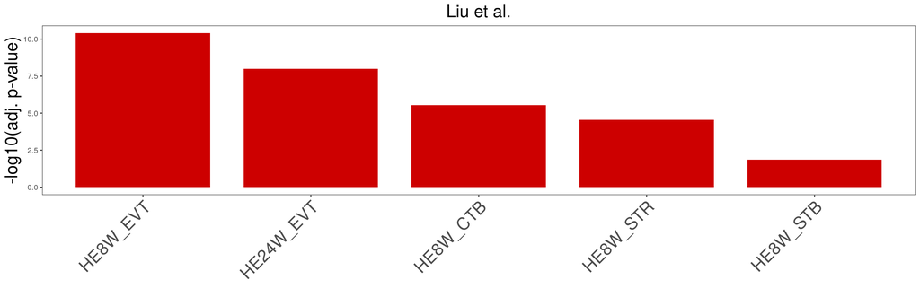

```r
#Liu et al. dataset
inputGenes<-toupper(c(s1$V1, s2$V1))
humanOrthologs<-ratHumanOrthologs[ratHumanOrthologs$Gene.name %in% inputGenes,]
inputGenes<-humanOrthologs$Human.gene.name
gs <- GeneSet(unique(inputGenes))
output.liu <- teEnrichmentCustom(gs, te.dataset)
en.output.liu <- setNames(data.frame(assay(output.liu[[1]]),
                                     row.names = rowData(output.liu[[1]])[, 1]), colData(output.liu[[1]])[, 1])
en.output.liu$Tissue <- row.names(en.output.liu)

en.output.liu <- subset(en.output.liu, en.output.liu$Log10PValue >= -log10(0.05) &
                          en.output.liu$fold.change >= 1.5 &
                          en.output.liu$Tissue.Specific.Genes >= 5)
en.output.liu <- en.output.liu[order(-en.output.liu$Log10PValue),]
#write.table(en.output.liu, "/work/LAS/geetu-lab/hhvu/project3_scATAC/scRNA-seq-analysis/7_conserved/liu.txt", sep = "\t", quote = F, row.names = T)

color <- rep("red3", dim(en.output.liu)[1])

plotFunc(en.output.liu, "Liu et al.")
```

```r
expressionData <- read.table("/work/LAS/geetu-lab/hhvu/project3_scATAC/scRNA-seq-analysis/7_conserved/liu.meanTPMlike_byCellTypes.txt", header = T)
tpm1genesLiu <- rownames(expressionData[(expressionData$HE8W_EVT >= 1 | expressionData$HE24W_EVT >= 1) & rownames(expressionData) %in% inputGenes, ])
```

We can see the genes showed strong enrichment for extravillous trophoblast cell-specific genes in all 5 datasets.

We then check the expression level of the genes in 2 additional datasets: bulk RNA-seq from Okae et al. and bulk RNA-seq from Morey et al.

```r
#okae
okae <- read.table("/work/LAS/geetu-lab/hhvu/project3_scATAC/scRNA-seq-analysis/7_conserved/Okae_et_al_Table_S1.csv", header = T, sep = ",")
okae_evt <- rowMeans(okae[,c("EVT_1", "EVT_2", "EVT_3")])
names(okae_evt) <- okae$Gene
tpm1genesOkae <- intersect(names(okae_evt[which(okae_evt >= 0)]), inputGenes)

#morey
morey <- read.table("/work/LAS/geetu-lab/hhvu/project3_scATAC/scRNA-seq-analysis/7_conserved/Morey_geneLvlTPM.txt", header = T)
samples <- read.table("/work/LAS/geetu-lab/hhvu/project3_scATAC/scRNA-seq-analysis/7_conserved/Morey_samples.txt", header = F)
samples$conditions <- sub("_patient.*", "", samples$V2)
samples$samples <- c(paste0("First_Trimester_CTB", "_", 1:10), paste0("Term_CTB", "_", 1:10),
                     paste0("First_Trimester_EVT", "_", 1:10), paste0("Term_EVT", "_", 1:6))
samples <- samples[match(samples$V1, colnames(morey)[1:(ncol(morey)-1)]),]
colnames(morey) <- c(samples$samples, "emsemblGenes")
morey$emsemblGenes <- substr(morey$emsemblGenes, 1, 15)
mean1 <- rowMeans(morey[,paste0("First_Trimester_EVT", "_", 1:10)])
names(mean1) <- morey$emsemblGenes
mean2 <- rowMeans(morey[,paste0("Term_EVT", "_", 1:6)])
names(mean2) <- morey$emsemblGenes

tpm1genesMorey <- ratHumanOrthologs[ratHumanOrthologs$Human.gene.stable.ID %in%
                                  c(names(mean1[which(mean1 >= 1)]), names(mean2[which(mean2 >= 1)])), ]
tpm1genesMorey <- intersect(tpm1genesMorey$Human.gene.name, inputGenes)
```

```r
#summary
df <- as.data.frame(matrix(nrow = length(unique(c(tpm1genesVT, tpm1genesSu, tpm1genesXi,
                                                  tpm1genesCas, tpm1genesLiu, tpm1genesOkae, tpm1genesMorey))), ncol = 7))
rownames(df) <- sort(unique(c(tpm1genesVT, tpm1genesSu, tpm1genesXi, tpm1genesCas, tpm1genesLiu,
                              tpm1genesOkae, tpm1genesMorey)))
colnames(df) <- c("VentoTormo", "Suryawanshi", "Xiang", "Castel", "Liu", "Okae", "Morey")
df$VentoTormo <- ifelse(row.names(df) %in% tpm1genesVT, 1, 0)
df$Suryawanshi <- ifelse(row.names(df) %in% tpm1genesSu, 1, 0)
df$Xiang <- ifelse(row.names(df) %in% tpm1genesXi, 1, 0)
df$Castel <- ifelse(row.names(df) %in% tpm1genesCas, 1, 0)
df$Liu <- ifelse(row.names(df) %in% tpm1genesLiu, 1, 0)
df$Okae <- ifelse(row.names(df) %in% tpm1genesOkae, 1, 0)
df$Morey <- ifelse(row.names(df) %in% tpm1genesMorey, 1, 0)
temp <- ratHumanOrthologs[ratHumanOrthologs$Human.gene.name %in% rownames(df),]
temp <- temp[order(temp$Human.gene.name),]
df$ratGenes <- temp$Gene.name
#save(df, file="/work/LAS/geetu-lab/hhvu/project3_scATAC/scRNA-seq-analysis/7_conserved/conservedRat.rda")
```

Looking at the number of genes expressed in datasets:

```r
df2 <- data.frame(SevenDats = length(which(rowSums(df[,1:7]) == 7)),
                  SixDats = length(which(rowSums(df[,1:7]) == 6)),
                  FiveDats = length(which(rowSums(df[,1:7]) == 5)),
                  FourDats = length(which(rowSums(df[,1:7]) == 4)),
                  ThreeDats = length(which(rowSums(df[,1:7]) == 3)),
                  TwoDats = length(which(rowSums(df[,1:7]) == 2)),
                  OneDats = length(which(rowSums(df[,1:7]) == 1)),
                  ZeroDats = length(unique(c(s1$V1, s2$V1)))-length(which(rowSums(df[,1:7]) >= 1)))
df2
```

```
#>   SevenDats SixDats FiveDats FourDats ThreeDats TwoDats OneDats ZeroDats
#> 1        77      45       27      154        31      46      31       82
```

```r
library("org.Rn.eg.db")
library("clusterProfiler")

load("/work/LAS/geetu-lab/hhvu/project3_scATAC/rnor6.rda")
go <- function(genes) {
  GO <- enrichGO(gene = genes, OrgDb=org.Rn.eg.db, ont = "BP", pvalueCutoff = 0.05, qvalueCutoff = 0.05, maxGSSize=500, readable = T, keyType = "ENSEMBL")
  goSimplify <- simplify(GO)
  res <- as.data.frame(goSimplify)
  res$Rank <- seq(1, nrow(res))
  res$GeneRatio <- sapply(strsplit(res$GeneRatio, "/"), function(x) as.numeric(x[1])/as.numeric(x[2]))
  res$BgRatio <- sapply(strsplit(res$BgRatio, "/"), function(x) as.numeric(x[1])/as.numeric(x[2]))
  res$Fold <- as.numeric(res$GeneRatio)/as.numeric(res$BgRatio)
  res <- res[res$qvalue <= 0.05 & res$Fold >= 2 & res$Count >= 5,]

  return(res)
}

genes <- df[which(rowSums(df[,1:7]) >= 2), "ratGenes"]
g <- rnor6[toupper(rnor6$gene_name) %in% genes,]
r <- go(g$ensembl_gene_id)
head(r)
```

```
#>                    ID                                 Description  GeneRatio
#> GO:0034446 GO:0034446 substrate adhesion-dependent cell spreading 0.04432133
#> GO:0031589 GO:0031589                     cell-substrate adhesion 0.07479224
#> GO:0001667 GO:0001667               ameboidal-type cell migration 0.07756233
#> GO:0007015 GO:0007015                 actin filament organization 0.07479224
#> GO:0001666 GO:0001666                         response to hypoxia 0.07479224
#> GO:0007229 GO:0007229         integrin-mediated signaling pathway 0.03601108
#>                BgRatio       pvalue     p.adjust       qvalue
#> GO:0034446 0.005857449 3.110281e-10 1.318137e-06 1.102677e-06
#> GO:0031589 0.019892130 3.949096e-09 8.368134e-06 7.000292e-06
#> GO:0001667 0.023777765 4.433617e-08 6.263222e-05 5.239446e-05
#> GO:0007015 0.022849852 7.254128e-08 7.685748e-05 6.429448e-05
#> GO:0001666 0.023893754 1.791187e-07 1.354829e-04 1.133371e-04
#> GO:0007229 0.005915444 2.086804e-07 1.354829e-04 1.133371e-04
#>                                                                                                                                                                           geneID
#> GO:0034446                                                                            Cib1/Parva/St6gal1/Coro1c/Pxn/Lamc1/Fermt2/Dbn1/Net1/Efna1/Lama5/Src/Lamb1/Fbln1/Parvb/Fn1
#> GO:0031589         Cib1/Parva/Iqgap1/Jup/St6gal1/Serpine1/Coro1c/Pxn/Lamc1/Fermt2/Dbn1/Net1/Nid1/Efna1/Itga1/Lama5/Src/Itgb6/Zyx/Adamts9/Lamb1/Actn1/Fbln1/Itga5/Parvb/Mmp12/Fn1
#> GO:0001667 Cib1/Igf2/Jup/Serpine1/Coro1c/Pxn/Fgfbp1/Gata3/Hmox1/Plk2/Efna1/Lama5/Dab2ip/Sema6d/Src/Pparg/Arhgdib/Adamts9/Klf4/Jun/Arf6/Lgmn/Cyp1b1/Mmp12/Amotl2/Fn1/Sema4c/Efnb1
#> GO:0007015              Ezr/Vasp/Plekhg2/Grb2/Coro1c/Pxn/Arpc1b/Lcp1/Dbn1/Trim27/Diaph1/Cotl1/Wipf1/Src/Zyx/Arpc4/Cald1/Tmsb10/Tpm2/Cfl2/Actn1/Arf6/Mtss1/Lima1/Cgnl1/Tmod3/Nck1
#> GO:0001666          Pdlim1/Ascl2/Cited2/Nos2/Alkbh5/Npm1/Serpine1/Ero1a/Eif4ebp1/Hmox1/Ddit4/Ada/Slc2a8/Src/Hk2/Gnb1/Nppb/Pink1/Slc2a1/Alad/Plod1/Pgf/Ldlr/Map2k1/Scap/Mmp12/Pam
#> GO:0007229                                                                                             Itgax/Pxn/Adamts3/Fermt2/Itga1/Lama5/Src/Itgb6/Zyx/Adamts9/Fgr/Tln1/Itga5
#>            Count Rank     Fold
#> GO:0034446    16    1 7.566660
#> GO:0031589    27    2 3.759891
#> GO:0001667    28    3 3.261969
#> GO:0007015    27    4 3.273205
#> GO:0001666    27    5 3.130201
#> GO:0007229    13    6 6.087638
```

```r
#write.table(r, "/work/LAS/geetu-lab/hhvu/project3_scATAC/scRNA-seq-analysis/7_conserved/conservedGenesGO.txt",
#            sep = "\t", quote = F, row.names = F)
```